# Differential abundance analysis of microbiome data

Antton Alberdi

2026-05-19

## Loading of required libraries

This Rmd is the executable version of the practical. Detailed explanations are in the [Week 21 practical wiki](https://github.com/GeoGenetics/NBIB25004U-Metagenomics-2026/wiki/Week-21-practical-sessions); the notes here only state what each chunk does and what to inspect.

Package context: [1. Load and Inspect the Data](https://github.com/GeoGenetics/NBIB25004U-Metagenomics-2026/wiki/Week-21-practical-sessions#-1-load-and-inspect-the-data).

```r
library(phyloseq)
library(vegan)
library(dplyr)
library(tibble)
library(purrr)
library(stringr)
library(ggplot2)
library(tidyverse)
library(ggh4x)
library(lme4)
library(lmerTest)
library(broom.mixed)
library(microbiome)
```

## Load and inspect the data

Details: [1. Load and Inspect the Data](https://github.com/GeoGenetics/NBIB25004U-Metagenomics-2026/wiki/Week-21-practical-sessions#-1-load-and-inspect-the-data). Load the saved `phyloseq` object, derive the practical metadata variables, and confirm that the abundance table, taxonomy table and sample metadata are present.

```r
ps <- readRDS("../data/phyloseq_augmented_v3.rds")

ps
```

```
## phyloseq-class experiment-level object
## otu_table()   OTU Table:         [ 173 taxa and 30 samples ]
## sample_data() Sample Data:       [ 30 samples by 3 sample variables ]
## tax_table()   Taxonomy Table:    [ 173 taxa by 7 taxonomic ranks ]
```

```r
sample_data(ps)
```

```
##            body_site    age  status
## ERR2641635       gut  adult healthy
## ERR2641677       gut  adult healthy
## ERR2641733       gut  adult healthy
## SRR8692206       gut infant healthy
## SRR8692207       gut infant    sick
## SRR8692213       gut infant    sick
## SRR059458    vaginal  adult healthy
## SRR059459    vaginal  adult healthy
## SRR513791    vaginal  adult healthy
## SIM2291543       gut  adult    sick
## SIM5894288       gut  adult    sick
## SIM8279698       gut  adult healthy
## SIM2306496       gut  adult healthy
## SIM8896464       gut  adult    sick
## SIM5814710       gut  adult healthy
## SIM8854893       gut  adult healthy
## SIM7844590       gut infant    sick
## SIM9454094       gut infant healthy
## SIM7706293       gut infant    sick
## SIM6665838       gut infant healthy
## SIM2278039       gut infant healthy
## SIM0948473       gut infant    sick
## SIM1026741       gut infant    sick
## SIM3538376   vaginal  adult healthy
## SIM9303320   vaginal  adult healthy
## SIM1138003   vaginal  adult healthy
## SIM9230613   vaginal  adult healthy
## SIM9542217   vaginal  adult healthy
## SIM3998642   vaginal  adult healthy
## SIM4532687   vaginal  adult healthy
```

```r
rank_names(ps)
```

```
## [1] "domain"  "phylum"  "class"   "order"   "family"  "genus"   "species"
```

```r
sample_variables(ps)
```

```
## [1] "body_site" "age"       "status"
```

Check that the expected metadata variables are present, especially `body_site`, `age` and `status`.

## Visualise community composition

Details: [2. Visualise Community Composition](https://github.com/GeoGenetics/NBIB25004U-Metagenomics-2026/wiki/Week-21-practical-sessions#-2-visualise-community-composition). Convert counts to relative abundance and plot genus-level composition across body site, age and health status.

[figure not shown]

```r
ps_rel <- transform_sample_counts(ps, function(x) x / sum(x))
otu_rel <- as(otu_table(ps_rel), "matrix") %>% t() %>% as.data.frame()
meta_rel <- as(sample_data(ps_rel), "matrix") %>% as.data.frame()
tax_rel <- as(tax_table(ps_rel), "matrix") %>% as.data.frame()

ps_genus <- tax_glom(ps_rel, taxrank = "genus")

plot_bar(ps_genus, fill = "genus") +
  facet_nested(~ body_site + age + status, scales = "free_x") +
  theme_bw() +
  theme(axis.text.x = element_blank())
```

Use the stacked bar plot to decide whether gut samples look distinct enough to analyse separately.

The hidden chunk below creates `dat_rel`, the long relative-abundance table used by the remaining relative-abundance analyses.

# Univariate statistics

These sections analyse taxa one at a time. Extended explanations are in the linked wiki sections.

## Explore individual taxa

Details: [3. Explore Individual Taxa](https://github.com/GeoGenetics/NBIB25004U-Metagenomics-2026/wiki/Week-21-practical-sessions#-3-explore-individual-taxa). Change `one_taxon` to inspect another taxon before running formal tests.

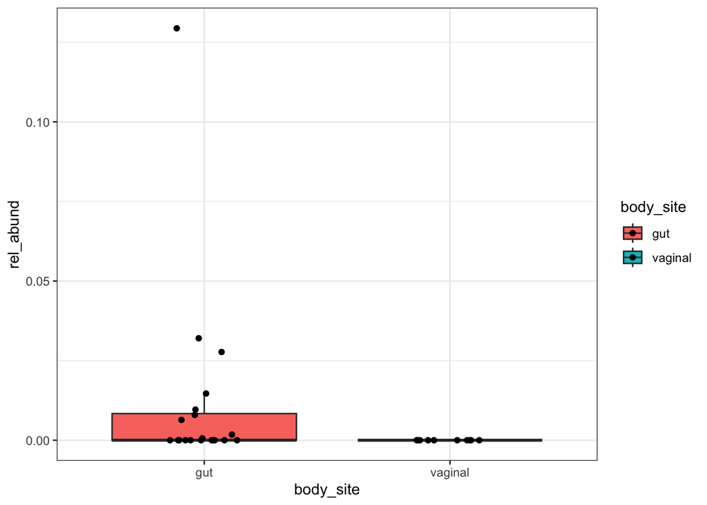

```r
one_taxon <- dat_rel$taxon[3]
#one_taxon <- dat_rel$taxon[5]
#one_taxon <- dat_rel$taxon[20]

# Comparison between body sites
dat_rel %>%
  filter(taxon == one_taxon) %>%
  ggplot(aes(x = body_site, y = rel_abund, fill = body_site)) +
    geom_boxplot(outlier.shape = NA) +
    geom_jitter(width = 0.15) +
    theme_bw()
```

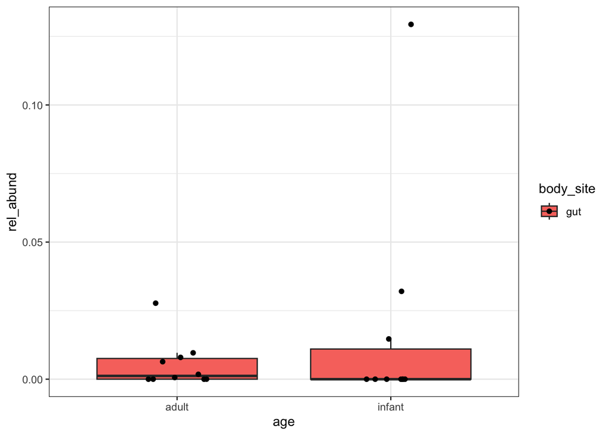

```r
# Comparison between ages within gut samples
dat_rel %>%
  filter(taxon == one_taxon) %>%
  filter(body_site == "gut") %>%
  ggplot(aes(x = age, y = rel_abund, fill = body_site)) +
    geom_boxplot(outlier.shape = NA) +
    geom_jitter(width = 0.15) +
    theme_bw()
```

Look for zeros, skew and raw age separation in the selected taxon.

## Diagnose the data before testing

Details: [4. Diagnose the Data Before Testing](https://github.com/GeoGenetics/NBIB25004U-Metagenomics-2026/wiki/Week-21-practical-sessions#-4-diagnose-the-data-before-testing). The next three chunks diagnose zero-inflation, skewness and non-normality among gut taxa.

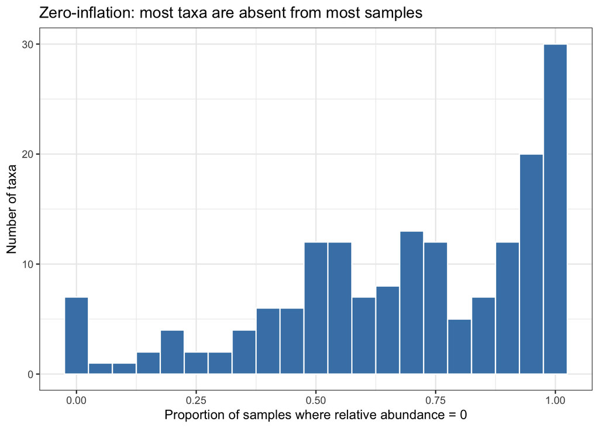

```r
dat_rel %>%
  filter(body_site == "gut") %>%
  group_by(taxon) %>%
  summarise(prop_zero = mean(rel_abund == 0), .groups = "drop") %>%
  ggplot(aes(x = prop_zero)) +
    geom_histogram(binwidth = 0.05, fill = "steelblue", color = "white") +
    labs(x = "Proportion of samples where relative abundance = 0",
         y = "Number of taxa",
         title = "Zero-inflation: most taxa are absent from most samples") +
    theme_bw()
```

High zero proportions mean many taxa have limited information for per-taxon testing.

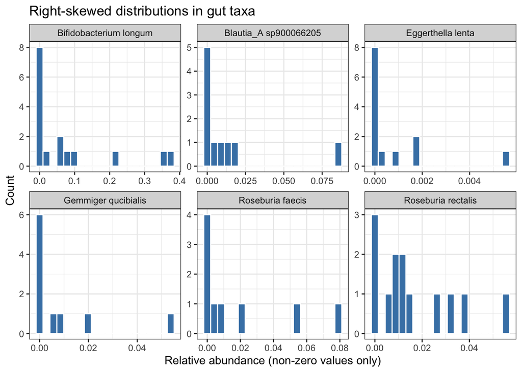

```r
set.seed(42)
example_taxa <- dat_rel %>%
  filter(body_site == "gut") %>%
  group_by(taxon, genus, species) %>%
  summarise(prop_nonzero = mean(rel_abund > 0), .groups = "drop") %>%
  filter(prop_nonzero > 0.4, prop_nonzero < 0.9) %>%
  slice_sample(n = 6) %>%
  pull(taxon)

dat_rel %>%
  filter(body_site == "gut", taxon %in% example_taxa, rel_abund > 0) %>%
  mutate(label = species) %>%
  ggplot(aes(x = rel_abund)) +
    geom_histogram(bins = 20, fill = "steelblue", color = "white") +
    facet_wrap(~ label, scales = "free") +
    labs(x = "Relative abundance (non-zero values only)",
         y = "Count",
         title = "Right-skewed distributions in gut taxa") +
    theme_bw()
```

Use these histograms to see whether non-zero abundances are dominated by a few high values.

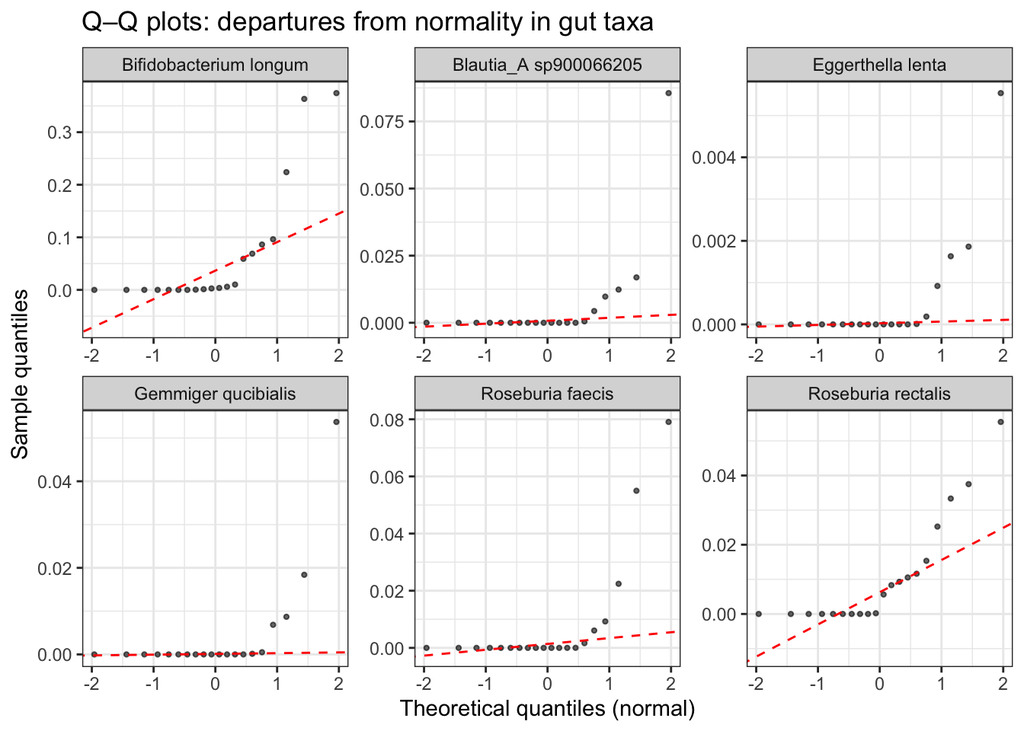

```r
dat_rel %>%
  filter(body_site == "gut", taxon %in% example_taxa) %>%
  mutate(label = species) %>%
  ggplot(aes(sample = rel_abund)) +
    stat_qq(size = 0.8, alpha = 0.6) +
    stat_qq_line(color = "red", linetype = "dashed") +
    facet_wrap(~ label, scales = "free") +
    labs(x = "Theoretical quantiles (normal)",
         y = "Sample quantiles",
         title = "Q–Q plots: departures from normality in gut taxa") +
    theme_bw()
```

Use the Q-Q plots as a visual check of normality on raw relative abundances.

## Wilcoxon rank-sum test

Details: [5. Wilcoxon Rank-Sum Test](https://github.com/GeoGenetics/NBIB25004U-Metagenomics-2026/wiki/Week-21-practical-sessions#-5-wilcoxon-rank-sum-test). This chunk runs one Wilcoxon test per gut taxon, compares infants with adults and adds a BH-adjusted `q_value`.

```r
wilcox_results <- dat_rel %>%
  filter(body_site == "gut") %>%
  group_by(taxon, genus, species) %>%
  summarise(
    p_value = wilcox.test(rel_abund ~ age, exact = FALSE)$p.value,
    mean_adult = mean(rel_abund[age == "adult"]),
    mean_infant = mean(rel_abund[age == "infant"]),
    log2_fc = log2((mean_adult + 1e-6) / (mean_infant + 1e-6)),
    .groups = "drop"
  ) %>%
  mutate(q_value = p.adjust(p_value, method = "BH"))
```

Positive `log2_fc` means adult-enriched; negative means infant-enriched. Interpret `q_value` using [8. Control False Discoveries with FDR](https://github.com/GeoGenetics/NBIB25004U-Metagenomics-2026/wiki/Week-21-practical-sessions#-8-control-false-discoveries-with-fdr).

The next table lists the strongest infant-enriched taxa.

```r
wilcox_infant_enriched <- wilcox_results %>%
  select(taxon, genus, species, mean_adult, mean_infant, log2_fc, p_value, q_value) %>%
  arrange(log2_fc) %>%
  head(10)

wilcox_infant_enriched
```

```
## # A tibble: 10 × 8
##    taxon            genus species mean_adult mean_infant log2_fc p_value q_value
##    <chr>            <chr> <chr>        <dbl>       <dbl>   <dbl>   <dbl>   <dbl>
##  1 SRR8692207_bin.… Bifi… Bifido…   0            0.0469   -15.5  0.168    0.359
##  2 SRR8692206_bin.… Clos… Clostr…   0            0.0257   -14.7  0.168    0.359
##  3 SRR8692207_bin.… Lact… Lactic…   0            0.0194   -14.2  0.368    0.506
##  4 SRR8692207_bin.3 Veil… Veillo…   1.40e- 8     0.00777  -12.9  0.0724   0.232
##  5 SRR8692207_bin.5 Cuti… Cutiba…   0            0.00757  -12.9  0.0779   0.232
##  6 SRR8692207_bin.… Bifi… Bifido…   0            0.00326  -11.7  0.368    0.506
##  7 SRR8692206_bin.… Paul… Paulje…   0            0.00209  -11.0  0.368    0.506
##  8 SRR8692207_bin.… Ente… Entero…   1.64e-13     0.00182  -10.8  0.456    0.577
##  9 SRR8692213_bin.… Kleb… Klebsi…   9.49e- 6     0.0153   -10.5  0.00533  0.0612
## 10 SRR8692213_bin.… Ente… Entero…   3.44e- 5     0.0272    -9.58 0.709    0.818
```

Inspect the top infant-enriched taxon in the raw data before trusting the table.

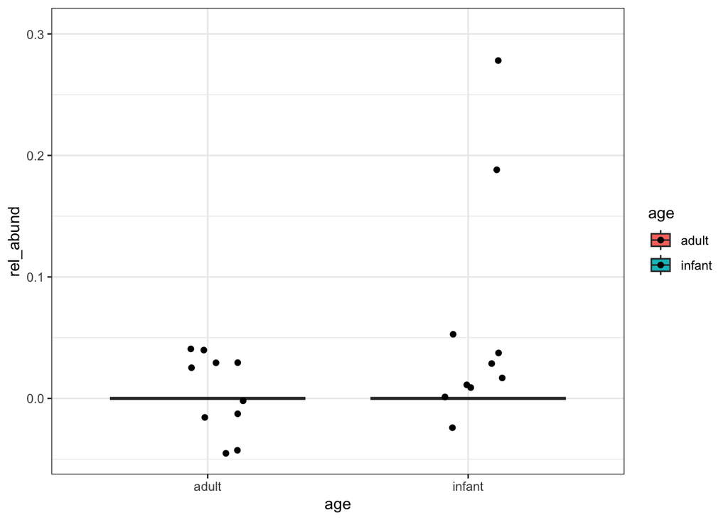

```r
dat_rel %>%
  filter(taxon == wilcox_infant_enriched %>% slice(1) %>% pull(taxon)) %>%
  filter(body_site == "gut") %>%
  ggplot(aes(x = age, y = rel_abund, fill = age)) +
    geom_boxplot(outlier.shape = NA) +
    geom_jitter(width = 0.15) +
    theme_bw()
```

Check whether the visual direction matches the negative `log2_fc`.

The next table lists the strongest adult-enriched taxa.

```r
wilcox_adult_enriched <- wilcox_results %>%
  select(taxon, genus, species, mean_adult, mean_infant, log2_fc, p_value, q_value) %>%
  arrange(-log2_fc) %>%
  head(10)

wilcox_adult_enriched
```

```
## # A tibble: 10 × 8
##    taxon            genus species mean_adult mean_infant log2_fc p_value q_value
##    <chr>            <chr> <chr>        <dbl>       <dbl>   <dbl>   <dbl>   <dbl>
##  1 ERR2641677_bin.… Rumi… Rumino…    0.0473     0           15.5 0.0149   0.100
##  2 ERR2641677_bin.… Rose… Rosebu…    0.0344     1.31e- 8    15.1 0.00382  0.0546
##  3 ERR2641677_bin.… Medi… Medite…    0.0325     2.18e-14    15.0 0.00382  0.0546
##  4 ERR2641677_bin.5 Acet… Acetat…    0.0127     1.86e-27    13.6 0.0296   0.151
##  5 ERR2641635_bin.… Faec… Faecal…    0.0100     3.28e-53    13.3 0.00915  0.0872
##  6 ERR2641635_bin.… Homi… Homini…    0.0100     6.13e-10    13.3 0.0239   0.131
##  7 ERR2641635_bin.… Rose… Rosebu…    0.0104     1.04e- 7    13.2 0.0837   0.235
##  8 ERR2641733_bin.… Rumi… Rumino…    0.0171     9.71e- 7    13.1 0.0187   0.112
##  9 ERR2641635_bin.… Euba… Eubact…    0.00850    3.96e- 9    13.0 0.0154   0.100
## 10 ERR2641677_bin.… Bact… Bacter…    0.00787    0           12.9 0.0779   0.232
```

Inspect the top adult-enriched taxon in the raw data.

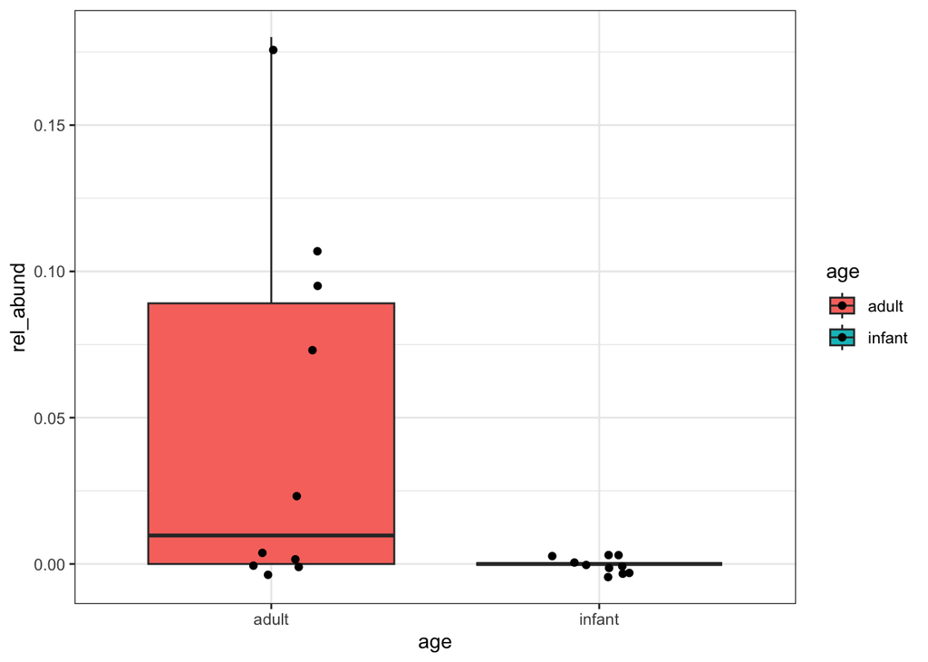

```r
dat_rel %>%
  filter(taxon == wilcox_adult_enriched %>% slice(1) %>% pull(taxon)) %>%
  filter(body_site == "gut") %>%
  ggplot(aes(x = age, y = rel_abund, fill = age)) +
    geom_boxplot(outlier.shape = NA) +
    geom_jitter(width = 0.15) +
    theme_bw()
```

Check whether the visual direction matches the positive `log2_fc`.

The volcano plot combines effect size and adjusted significance for the Wilcoxon results.

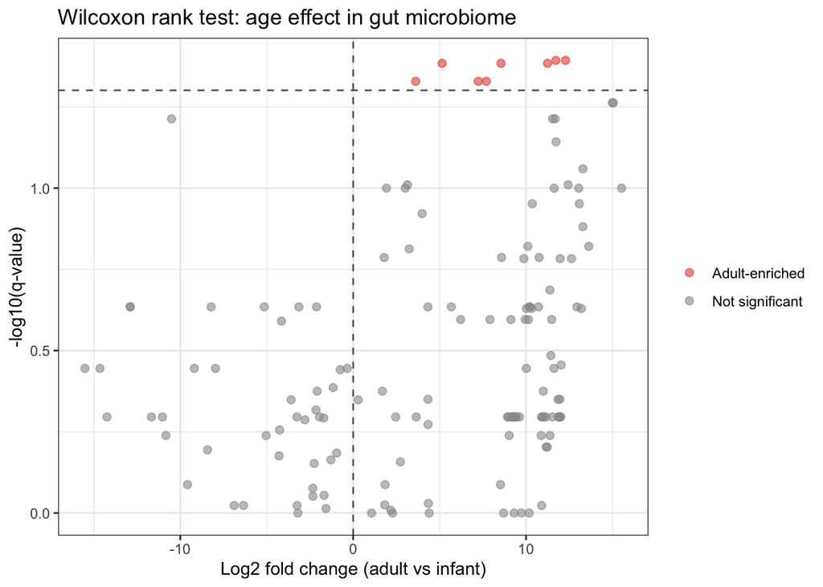

```r
# Volcano plot: Wilcoxon rank test
wilcox_results %>%
  mutate(
    neg_log10_q = -log10(q_value),
    direction = case_when(
      q_value < 0.05 & log2_fc > 0 ~ "Adult-enriched",
      q_value < 0.05 & log2_fc < 0 ~ "Infant-enriched",
      TRUE ~ "Not significant"
    )
  ) %>%
  ggplot(aes(x = log2_fc, y = neg_log10_q, color = direction)) +
    geom_point(alpha = 0.6, size = 2) +
    scale_color_manual(values = c("Adult-enriched" = "#E74C3C", "Infant-enriched" = "#3498DB", "Not significant" = "grey60")) +
    geom_hline(yintercept = -log10(0.05), linetype = "dashed", color = "grey40") +
    geom_vline(xintercept = 0, linetype = "dashed", color = "grey40") +
    labs(x = "Log2 fold change (adult vs infant)", y = "-log10(q-value)", color = NULL,
         title = "Wilcoxon rank test: age effect in gut microbiome") +
    theme_bw()
```

Use the volcano plot to identify taxa that are both large-effect and statistically supported.

The next plot shows Wilcoxon effect size on the x-axis and orders taxa by q-value.

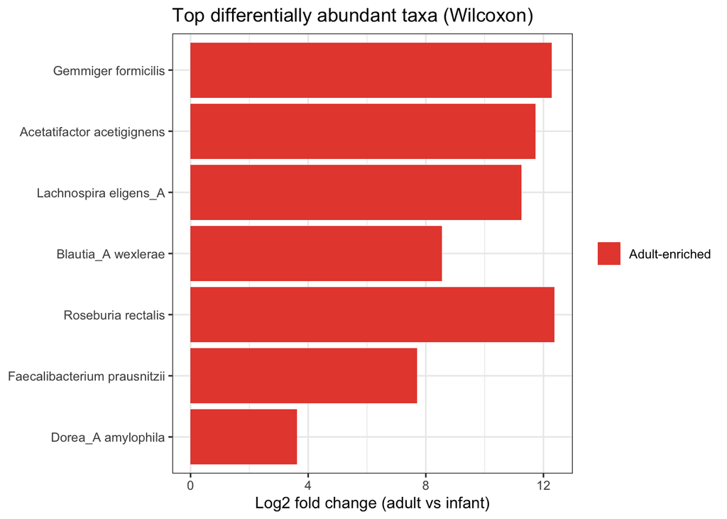

```r
# Bar chart of top significant taxa ordered by q-value (Wilcoxon)
bind_rows(
  wilcox_results %>% filter(q_value < 0.05) %>% arrange(log2_fc) %>% head(10),
  wilcox_results %>% filter(q_value < 0.05) %>% arrange(-log2_fc) %>% head(10)
) %>%
  distinct() %>%
  mutate(
    label = species,
    direction = ifelse(log2_fc > 0, "Adult-enriched", "Infant-enriched")
  ) %>%
  ggplot(aes(x = reorder(label, -q_value), y = log2_fc, fill = direction)) +
    geom_col() +
    coord_flip() +
    scale_fill_manual(values = c("Adult-enriched" = "#E74C3C", "Infant-enriched" = "#3498DB")) +
    labs(x = NULL, y = "Log2 fold change (adult vs infant)", fill = NULL,
         title = "Top differentially abundant taxa (Wilcoxon)") +
    theme_bw()
```

Use the bar chart as a first-pass rank list, then compare it with the model-based analyses below.

## Age difference using log-transformed linear models

Details: [6. Age Difference Using Log-Transformed Linear Models](https://github.com/GeoGenetics/NBIB25004U-Metagenomics-2026/wiki/Week-21-practical-sessions#-6-age-difference-using-log-transformed-linear-models). Fit one age-only model per taxon on `log10(rel_abund + 1e-6)`.

```r
glm_age_results <- dat_rel %>%
  filter(body_site == "gut") %>%
  mutate(
    age = factor(age, levels = c("infant", "adult"))
  ) %>%
  group_by(taxon, genus, species) %>%
  group_modify(~ {
    fit <- glm(
      log10(rel_abund + 1e-6) ~ age,
      data = .x,
      family = gaussian()
    )

    broom::tidy(fit)
  }) %>%
  ungroup() %>%
  filter(term == "ageadult") %>%
  mutate(
    q_value = p.adjust(p.value, method = "BH"),
    fold_change_adult_vs_infant = 10^estimate
  )
```

The `estimate` is adult minus infant on the log10 scale; `10^estimate` gives the fold change. The next table lists infant-enriched taxa.

```r
glm_infant_enriched <- glm_age_results %>%
  select(taxon, genus, species, estimate, fold_change_adult_vs_infant, std.error, statistic, p.value, q_value) %>%
  arrange(fold_change_adult_vs_infant) %>%
  head(10)

glm_infant_enriched
```

```
## # A tibble: 10 × 9
##    taxon       genus species estimate fold_change_adult_vs…¹ std.error statistic
##    <chr>       <chr> <chr>      <dbl>                  <dbl>     <dbl>     <dbl>
##  1 SRR8692207… Veil… Veillo…    -1.95                 0.0112     0.629     -3.10
##  2 SRR8692213… Kleb… Klebsi…    -1.75                 0.0179     0.713     -2.45
##  3 SRR8692206… Veil… Veillo…    -1.43                 0.0368     0.749     -1.91
##  4 SRR8692213… Stre… Strept…    -1.37                 0.0428     0.621     -2.20
##  5 SRR8692206… Stre… Strept…    -1.21                 0.0611     0.620     -1.96
##  6 SRR8692213… Ente… Entero…    -1.16                 0.0691     0.768     -1.51
##  7 SRR8692213… Stre… Strept…    -1.15                 0.0704     0.865     -1.33
##  8 SRR8692213… Para… Paraba…    -1.13                 0.0734     0.972     -1.17
##  9 SRR8692207… Bifi… Bifido…    -1.07                 0.0851     0.714     -1.50
## 10 SRR8692207… Cuti… Cutiba…    -1.04                 0.0908     0.585     -1.78
## # ℹ abbreviated name: ¹fold_change_adult_vs_infant
## # ℹ 2 more variables: p.value <dbl>, q_value <dbl>
```

Check the raw distribution of the top GLM infant-enriched taxon.

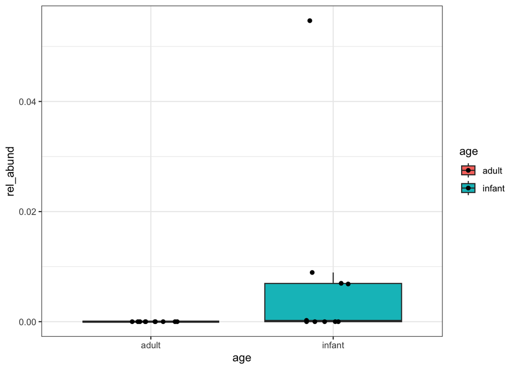

```r
dat_rel %>%
  filter(taxon == glm_infant_enriched %>% slice(1) %>% pull(taxon)) %>%
  filter(body_site == "gut") %>%
  ggplot(aes(x = age, y = rel_abund, fill = age)) +
    geom_boxplot(outlier.shape = NA) +
    geom_jitter(width = 0.15) +
    theme_bw()
```

Look for outliers or unequal spread that might explain disagreement with Wilcoxon.

The next table lists adult-enriched taxa from the age-only GLM.

```r
glm_adult_enriched <- glm_age_results %>%
  select(taxon, genus, species, estimate, fold_change_adult_vs_infant, std.error, statistic, p.value, q_value) %>%
  arrange(-fold_change_adult_vs_infant) %>%
  head(10)

glm_adult_enriched
```

```
## # A tibble: 10 × 9
##    taxon       genus species estimate fold_change_adult_vs…¹ std.error statistic
##    <chr>       <chr> <chr>      <dbl>                  <dbl>     <dbl>     <dbl>
##  1 ERR2641677… Rose… Rosebu…     3.38                  2425.     0.592      5.71
##  2 ERR2641677… Blau… Blauti…     3.33                  2138.     0.603      5.52
##  3 ERR2641677… Faec… Faecal…     3.23                  1700.     0.677      4.78
##  4 ERR2641677… Rose… Rosebu…     3.17                  1496.     0.600      5.30
##  5 ERR2641677… Medi… Medite…     2.73                   536.     0.682      4.00
##  6 ERR2641635… Rose… Rosebu…     2.69                   484.     0.606      4.43
##  7 ERR2641635… Homi… Homini…     2.56                   367.     0.589      4.36
##  8 ERR2641635… Euba… Eubact…     2.51                   321.     0.613      4.09
##  9 ERR2641635… Rose… Rosebu…     2.45                   284.     0.677      3.62
## 10 ERR2641677… Rumi… Rumino…     2.44                   276.     0.817      2.99
## # ℹ abbreviated name: ¹fold_change_adult_vs_infant
## # ℹ 2 more variables: p.value <dbl>, q_value <dbl>
```

Check the raw distribution of the top GLM adult-enriched taxon.

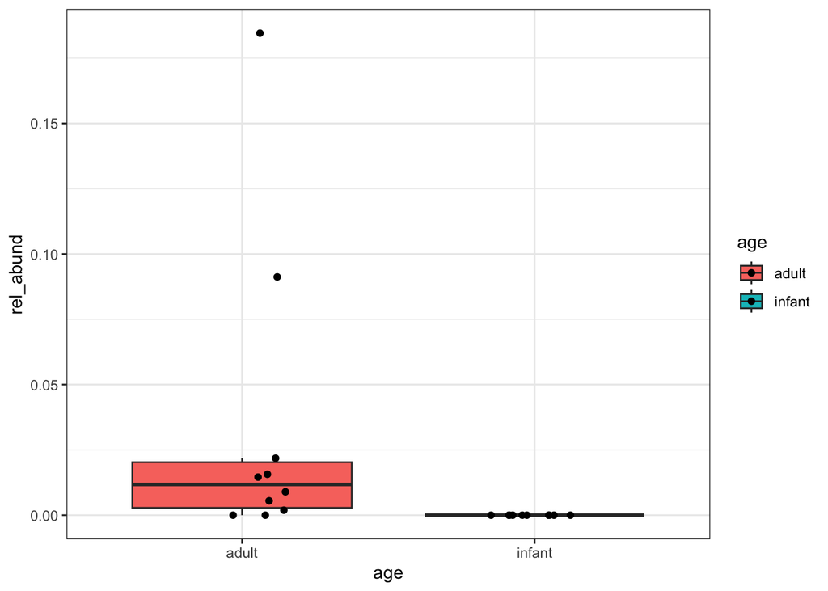

```r
dat_rel %>%
  filter(taxon == glm_adult_enriched %>% slice(1) %>% pull(taxon)) %>%
  filter(body_site == "gut") %>%
  ggplot(aes(x = age, y = rel_abund, fill = age)) +
    geom_boxplot(outlier.shape = NA) +
    geom_jitter(width = 0.15) +
    theme_bw()
```

Compare the plot direction with the GLM estimate and q-value.

The GLM volcano plot uses the model estimate as the effect-size axis.

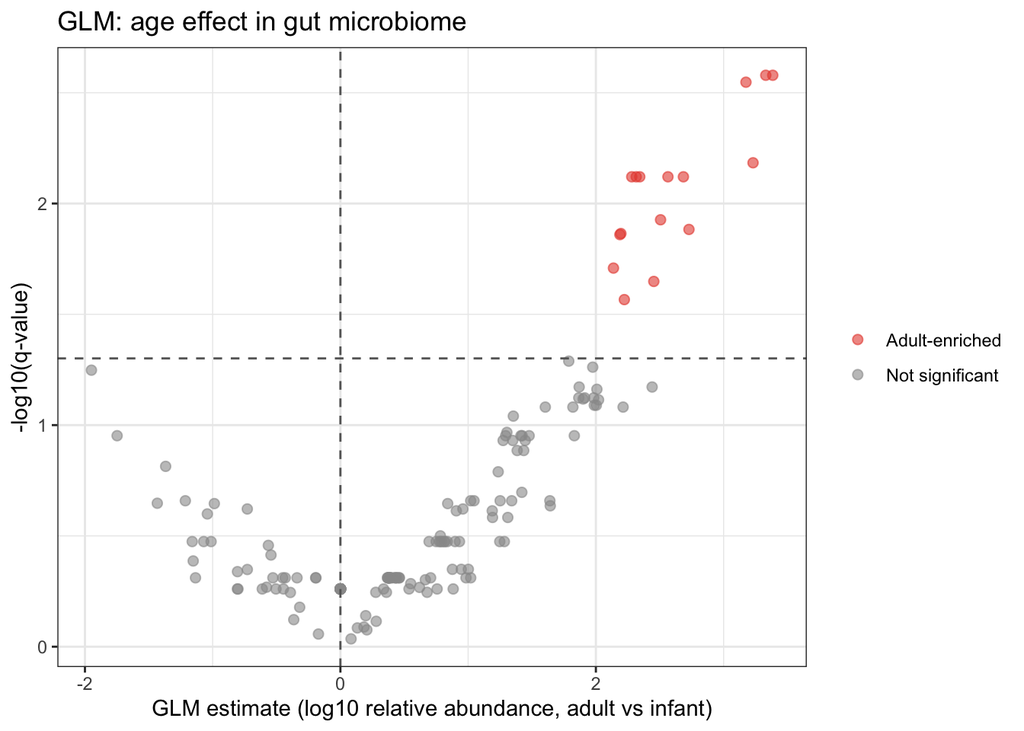

```r
# Volcano plot: GLM (unadjusted)
glm_age_results %>%
  mutate(
    neg_log10_q = -log10(q_value),
    direction = case_when(
      q_value < 0.05 & estimate > 0 ~ "Adult-enriched",
      q_value < 0.05 & estimate < 0 ~ "Infant-enriched",
      TRUE ~ "Not significant"
    )
  ) %>%
  ggplot(aes(x = estimate, y = neg_log10_q, color = direction)) +
    geom_point(alpha = 0.6, size = 2) +
    scale_color_manual(values = c("Adult-enriched" = "#E74C3C", "Infant-enriched" = "#3498DB", "Not significant" = "grey60")) +
    geom_hline(yintercept = -log10(0.05), linetype = "dashed", color = "grey40") +
    geom_vline(xintercept = 0, linetype = "dashed", color = "grey40") +
    labs(x = "GLM estimate (log10 relative abundance, adult vs infant)", y = "-log10(q-value)", color = NULL,
         title = "GLM: age effect in gut microbiome") +
    theme_bw()
```

Compare the overall pattern with the Wilcoxon volcano plot, remembering the effect-size scales differ.

The next plot shows GLM effect size on the x-axis and orders taxa by q-value.

[figure not shown]

```r
# Bar chart of top significant taxa ordered by q-value (GLM)
bind_rows(
  glm_age_results %>% filter(q_value < 0.05) %>% arrange(estimate) %>% head(10),
  glm_age_results %>% filter(q_value < 0.05) %>% arrange(-estimate) %>% head(10)
) %>%
  distinct() %>%
  mutate(
    label = species,
    direction = ifelse(estimate > 0, "Adult-enriched", "Infant-enriched")
  ) %>%
  ggplot(aes(x = reorder(label, -q_value), y = estimate, fill = direction)) +
    geom_col() +
    coord_flip() +
    scale_fill_manual(values = c("Adult-enriched" = "#E74C3C", "Infant-enriched" = "#3498DB")) +
    labs(x = NULL, y = "GLM estimate (log10 relative abundance)", fill = NULL,
         title = "Top differentially abundant taxa (GLM)") +
    theme_bw()
```

Differences from the Wilcoxon ranking are useful cases to discuss.

## Adjust the linear model for health status

Details: [7. Adjust the Linear Model for Health Status](https://github.com/GeoGenetics/NBIB25004U-Metagenomics-2026/wiki/Week-21-practical-sessions#-7-adjust-the-linear-model-for-health-status). Refit the log-transformed model with `status` as a covariate and keep the adjusted age coefficient.

```r
glm_age_adjusted_status_results <- dat_rel %>%
  filter(body_site == "gut") %>%
  mutate(
    age = factor(age, levels = c("infant", "adult")),
    status = factor(status, levels = c("healthy", "sick"))
  ) %>%
  group_by(taxon, genus, species) %>%
  group_modify(~ {
    fit <- glm(
      log10(rel_abund + 1e-6) ~ age + status,
      data = .x,
      family = gaussian()
    )

    broom::tidy(fit)
  }) %>%
  ungroup() %>%
  filter(term == "ageadult") %>%
  mutate(
    q_value = p.adjust(p.value, method = "BH"),
    fold_change_adult_vs_infant_adjusted_for_status = 10^estimate
  )
```

The retained term `ageadult` is the age effect after accounting for health status. The next table lists adjusted infant-enriched taxa.

```r
glm_adj_infant_enriched <- glm_age_adjusted_status_results %>%
  select(taxon, genus, species, estimate, fold_change_adult_vs_infant_adjusted_for_status, std.error, statistic, p.value, q_value) %>%
  arrange(fold_change_adult_vs_infant_adjusted_for_status) %>%
  head(10)

glm_adj_infant_enriched
```

```
## # A tibble: 10 × 9
##    taxon       genus species estimate fold_change_adult_vs…¹ std.error statistic
##    <chr>       <chr> <chr>      <dbl>                  <dbl>     <dbl>     <dbl>
##  1 SRR8692207… Veil… Veillo…    -2.06                0.00867     0.673     -3.06
##  2 SRR8692213… Para… Paraba…    -1.64                0.0227      0.965     -1.70
##  3 SRR8692206… Veil… Veillo…    -1.63                0.0236      0.793     -2.05
##  4 SRR8692213… Stre… Strept…    -1.50                0.0315      0.661     -2.27
##  5 SRR8692206… Stre… Strept…    -1.47                0.0338      0.637     -2.31
##  6 SRR8692213… Kleb… Klebsi…    -1.47                0.0339      0.737     -2.00
##  7 SRR8692206… Clos… Clostr…    -1.42                0.0382      0.652     -2.17
##  8 SRR8692213… Stre… Strept…    -1.36                0.0434      0.918     -1.48
##  9 SRR8692207… Para… Paraba…    -1.25                0.0558      0.829     -1.51
## 10 SRR8692206… Lact… Lactob…    -1.23                0.0589      0.622     -1.98
## # ℹ abbreviated name: ¹fold_change_adult_vs_infant_adjusted_for_status
## # ℹ 2 more variables: p.value <dbl>, q_value <dbl>
```

Compare these values with the unadjusted GLM to identify taxa affected by status adjustment.

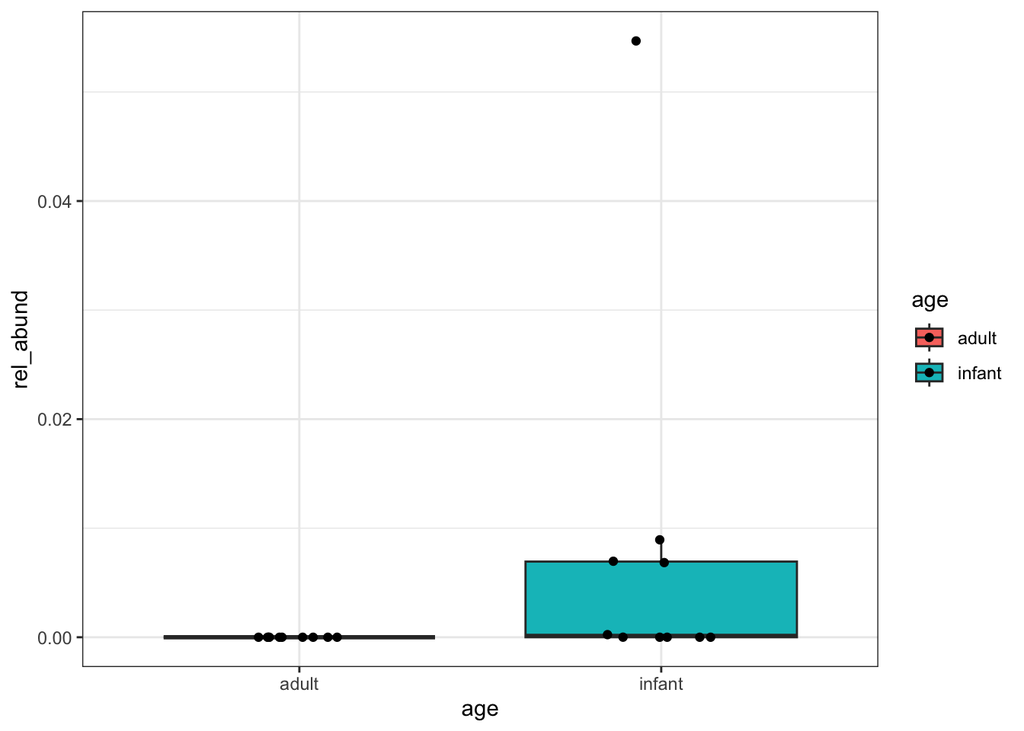

```r
dat_rel %>%
  filter(taxon == glm_adj_infant_enriched %>% slice(1) %>% pull(taxon)) %>%
  filter(body_site == "gut") %>%
  ggplot(aes(x = age, y = rel_abund, fill = age)) +
    geom_boxplot(outlier.shape = NA) +
    geom_jitter(width = 0.15) +
    theme_bw()
```

The plot is marginal over status, so use it as a visual check rather than a replacement for the adjusted model.

The next table lists adjusted adult-enriched taxa.

```r
glm_adj_adult_enriched <- glm_age_adjusted_status_results %>%
  select(taxon, genus, species, estimate, fold_change_adult_vs_infant_adjusted_for_status, std.error, statistic, p.value, q_value) %>%
  arrange(-fold_change_adult_vs_infant_adjusted_for_status) %>%
  head(10)

glm_adj_adult_enriched
```

```
## # A tibble: 10 × 9
##    taxon       genus species estimate fold_change_adult_vs…¹ std.error statistic
##    <chr>       <chr> <chr>      <dbl>                  <dbl>     <dbl>     <dbl>
##  1 ERR2641677… Blau… Blauti…     3.45                  2839.     0.643      5.37
##  2 ERR2641677… Rose… Rosebu…     3.39                  2453.     0.639      5.30
##  3 ERR2641677… Faec… Faecal…     3.21                  1628.     0.730      4.40
##  4 ERR2641677… Rose… Rosebu…     3.05                  1125.     0.639      4.77
##  5 ERR2641677… Rumi… Rumino…     2.64                   434.     0.867      3.04
##  6 ERR2641635… Euba… Eubact…     2.55                   351.     0.660      3.85
##  7 SRR8692207… Phoc… Phocae…     2.52                   334.     0.652      3.87
##  8 ERR2641677… Medi… Medite…     2.51                   326.     0.715      3.52
##  9 ERR2641635… Lach… Lachno…     2.47                   293.     0.550      4.49
## 10 ERR2641733… Phoc… Phocae…     2.40                   254.     0.872      2.76
## # ℹ abbreviated name: ¹fold_change_adult_vs_infant_adjusted_for_status
## # ℹ 2 more variables: p.value <dbl>, q_value <dbl>
```

Check the top adjusted adult-enriched taxon in the raw data.

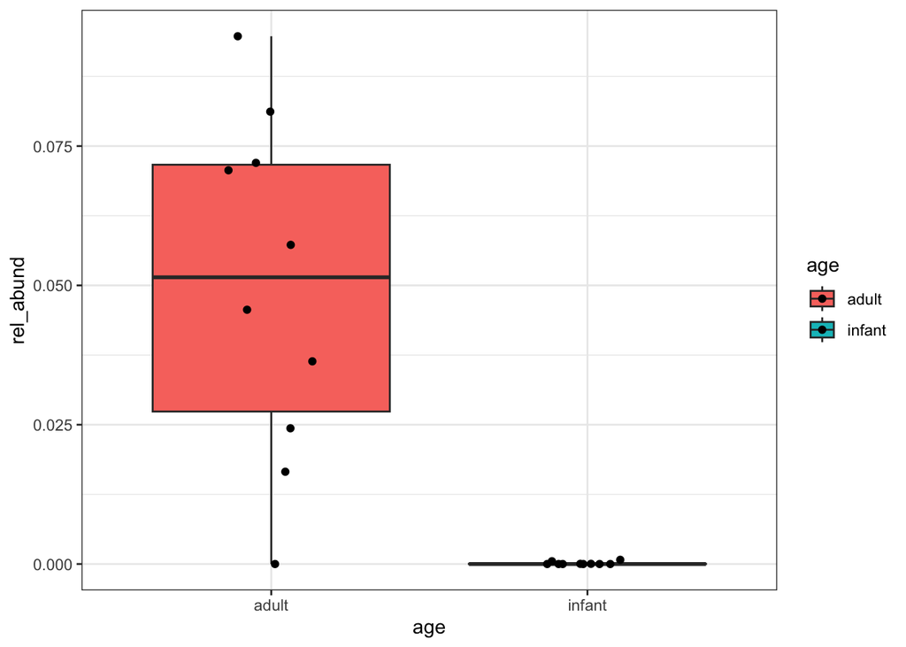

```r
dat_rel %>%
  filter(taxon == glm_adj_adult_enriched %>% slice(1) %>% pull(taxon)) %>%
  filter(body_site == "gut") %>%
  ggplot(aes(x = age, y = rel_abund, fill = age)) +
    geom_boxplot(outlier.shape = NA) +
    geom_jitter(width = 0.15) +
    theme_bw()
```

If the raw plot and adjusted estimate disagree, status may be influencing the marginal pattern.

The next volcano plot summarises the status-adjusted model results.

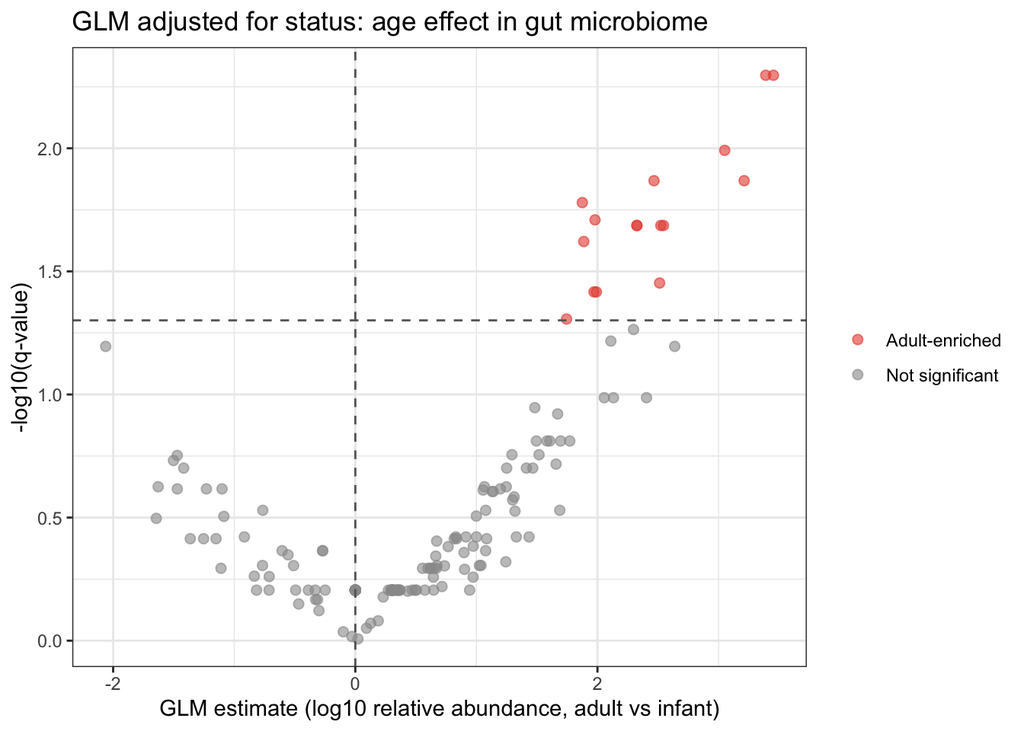

```r
# Volcano plot: GLM adjusted for health status
glm_age_adjusted_status_results %>%
  mutate(
    neg_log10_q = -log10(q_value),
    direction = case_when(
      q_value < 0.05 & estimate > 0 ~ "Adult-enriched",
      q_value < 0.05 & estimate < 0 ~ "Infant-enriched",
      TRUE ~ "Not significant"
    )
  ) %>%
  ggplot(aes(x = estimate, y = neg_log10_q, color = direction)) +
    geom_point(alpha = 0.6, size = 2) +
    scale_color_manual(values = c("Adult-enriched" = "#E74C3C", "Infant-enriched" = "#3498DB", "Not significant" = "grey60")) +
    geom_hline(yintercept = -log10(0.05), linetype = "dashed", color = "grey40") +
    geom_vline(xintercept = 0, linetype = "dashed", color = "grey40") +
    labs(x = "GLM estimate (log10 relative abundance, adult vs infant)", y = "-log10(q-value)", color = NULL,
         title = "GLM adjusted for status: age effect in gut microbiome") +
    theme_bw()
```

Compare this to the unadjusted GLM volcano to see which taxa move after adjustment.

The next plot shows adjusted GLM effect size on the x-axis and orders taxa by q-value.

[figure not shown]

```r
# Bar chart of top significant taxa ordered by q-value (GLM adjusted)
bind_rows(
  glm_age_adjusted_status_results %>% filter(q_value < 0.05) %>% arrange(estimate) %>% head(10),
  glm_age_adjusted_status_results %>% filter(q_value < 0.05) %>% arrange(-estimate) %>% head(10)
) %>%
  distinct() %>%
  mutate(
    label = species,
    direction = ifelse(estimate > 0, "Adult-enriched", "Infant-enriched")
  ) %>%
  ggplot(aes(x = reorder(label, -q_value), y = estimate, fill = direction)) +
    geom_col() +
    coord_flip() +
    scale_fill_manual(values = c("Adult-enriched" = "#E74C3C", "Infant-enriched" = "#3498DB")) +
    labs(x = NULL, y = "GLM estimate adjusted (log10 relative abundance)", fill = NULL,
         title = "Top differentially abundant taxa (GLM adjusted for status)") +
    theme_bw()
```

Taxa stable before and after adjustment are stronger age-associated candidates.

## Compositional analysis with CLR transformation

Details: [9. Compositional Analysis with CLR Transformation](https://github.com/GeoGenetics/NBIB25004U-Metagenomics-2026/wiki/Week-21-practical-sessions#-9-compositional-analysis-with-clr-transformation). Transform counts with CLR before fitting the adjusted age model on a compositional scale.

```r
ps_clr <- transform_sample_counts(ps, function(x) {
  x <- x + 1e-9
  log(x) - mean(log(x))
})
otu_clr <- as(otu_table(ps_clr), "matrix") %>% t() %>% as.data.frame()
meta_clr <- as(sample_data(ps_clr), "matrix") %>% as.data.frame()
tax_clr <- as(tax_table(ps_clr), "matrix") %>% as.data.frame()
```

The hidden chunk below reshapes CLR values into the long table `dat_clr`.

Fit one adjusted linear model per taxon using CLR values as the response.

```r
clr_age_adjusted_status_results <- dat_clr %>%
  filter(body_site == "gut") %>%
  mutate(
    age = factor(age, levels = c("infant", "adult")),
    status = factor(status, levels = c("healthy", "sick"))
  ) %>%
  group_by(taxon, genus, species) %>%
  group_modify(~ {
    fit <- lm(
      clr ~ age + status,
      data = .x
    )

    broom::tidy(fit)
  }) %>%
  ungroup() %>%
  filter(term == "ageadult") %>%
  mutate(q_value = p.adjust(p.value, method = "BH"))
```

Positive CLR estimates indicate adult enrichment relative to the community geometric mean; negative estimates indicate infant enrichment. The next table lists infant-enriched taxa.

```r
clr_infant_enriched <- clr_age_adjusted_status_results %>%
  select(taxon, genus, species, estimate, std.error, statistic, p.value, q_value) %>%
  arrange(estimate) %>%
  head(10)

clr_infant_enriched
```

```
## # A tibble: 10 × 8
##    taxon             genus  species estimate std.error statistic p.value q_value
##    <chr>             <chr>  <chr>      <dbl>     <dbl>     <dbl>   <dbl>   <dbl>
##  1 SRR8692207_bin.3  Veill… Veillo…   -13.9       3.63     -3.82 0.00138  0.0350
##  2 SRR8692213_bin.12 Parab… Paraba…   -12.0       4.05     -2.97 0.00868  0.0458
##  3 SRR8692206_bin.30 Veill… Veillo…   -11.2       4.28     -2.61 0.0182   0.0617
##  4 SRR8692206_bin.27 Strep… Strept…   -10.9       3.22     -3.37 0.00367  0.0458
##  5 SRR8692213_bin.10 Klebs… Klebsi…   -10.1       3.62     -2.79 0.0126   0.0458
##  6 SRR8692206_bin.18 Lacto… Lactob…    -9.39      3.88     -2.42 0.0270   0.0739
##  7 SRR8692207_bin.22 Enter… Entero…    -9.23      3.20     -2.88 0.0104   0.0458
##  8 SRR8692206_bin.12 Clost… Clostr…    -9.15      3.27     -2.80 0.0123   0.0458
##  9 SRR8692207_bin.5  Cutib… Cutiba…    -8.47      3.27     -2.59 0.0191   0.0622
## 10 SRR8692213_bin.13 Strep… Strept…    -8.45      3.45     -2.45 0.0257   0.0716
```

Inspect the top CLR infant-enriched taxon on the CLR scale.

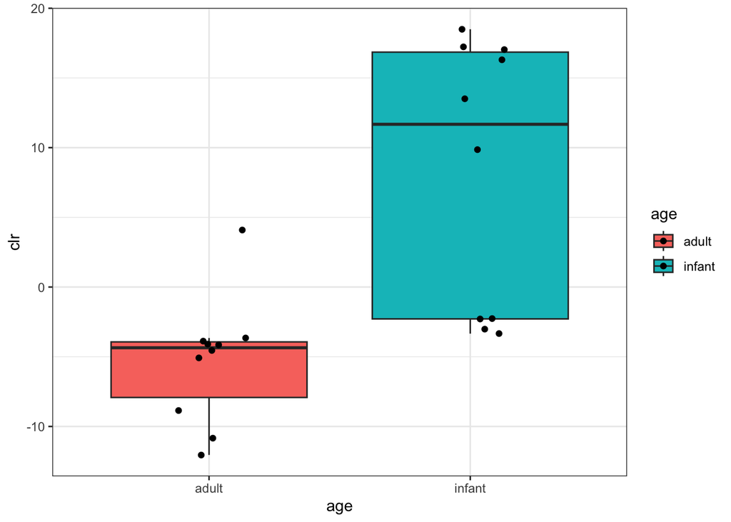

```r
dat_clr %>%
  filter(taxon == clr_infant_enriched %>% slice(1) %>% pull(taxon)) %>%
  filter(body_site == "gut") %>%
  ggplot(aes(x = age, y = clr, fill = age)) +
    geom_boxplot(outlier.shape = NA) +
    geom_jitter(width = 0.15) +
    theme_bw()
```

The y-axis is CLR, not relative abundance; compare direction rather than raw magnitude with earlier plots.

The next table lists CLR adult-enriched taxa.

```r
clr_adult_enriched <- clr_age_adjusted_status_results %>%
  select(taxon, genus, species, estimate, std.error, statistic, p.value, q_value) %>%
  arrange(-estimate) %>%
  head(10)

clr_adult_enriched
```

```
## # A tibble: 10 × 8
##    taxon             genus  species estimate std.error statistic p.value q_value
##    <chr>             <chr>  <chr>      <dbl>     <dbl>     <dbl>   <dbl>   <dbl>
##  1 ERR2641677_bin.28 Roseb… Rosebu…    12.1       3.23      3.74 1.62e-3  0.0350
##  2 ERR2641677_bin.43 Faeca… Faecal…    11.6       3.56      3.25 4.67e-3  0.0458
##  3 ERR2641635_bin.13 Lachn… Lachno…    11.3       2.58      4.37 4.17e-4  0.0276
##  4 ERR2641733_bin.62 Aceta… Acetat…    10.7       2.20      4.88 1.40e-4  0.0243
##  5 ERR2641677_bin.18 Medit… Medite…    10.7       2.64      4.06 8.14e-4  0.0350
##  6 ERR2641733_bin.23 Anthr… Anthro…    10.1       2.35      4.31 4.79e-4  0.0276
##  7 ERR2641677_bin.4  Blaut… Blauti…     9.88      3.58      2.76 1.34e-2  0.0463
##  8 ERR2641677_bin.46 Roseb… Rosebu…     9.77      3.50      2.79 1.26e-2  0.0458
##  9 ERR2641635_bin.30 Eubac… Eubact…     9.62      3.11      3.09 6.64e-3  0.0458
## 10 ERR2641733_bin.87 Phoca… Phocae…     9.60      3.84      2.50 2.30e-2  0.0674
```

Inspect the top CLR adult-enriched taxon on the CLR scale.

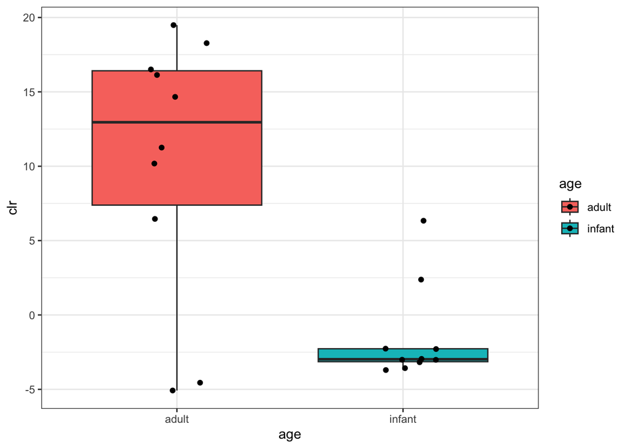

```r
dat_clr %>%
  filter(taxon == clr_adult_enriched %>% slice(1) %>% pull(taxon)) %>%
  filter(body_site == "gut") %>%
  ggplot(aes(x = age, y = clr, fill = age)) +
    geom_boxplot(outlier.shape = NA) +
    geom_jitter(width = 0.15) +
    theme_bw()
```

Check whether the group separation matches the CLR estimate and q-value.

The CLR volcano plot summarises the compositional model results.

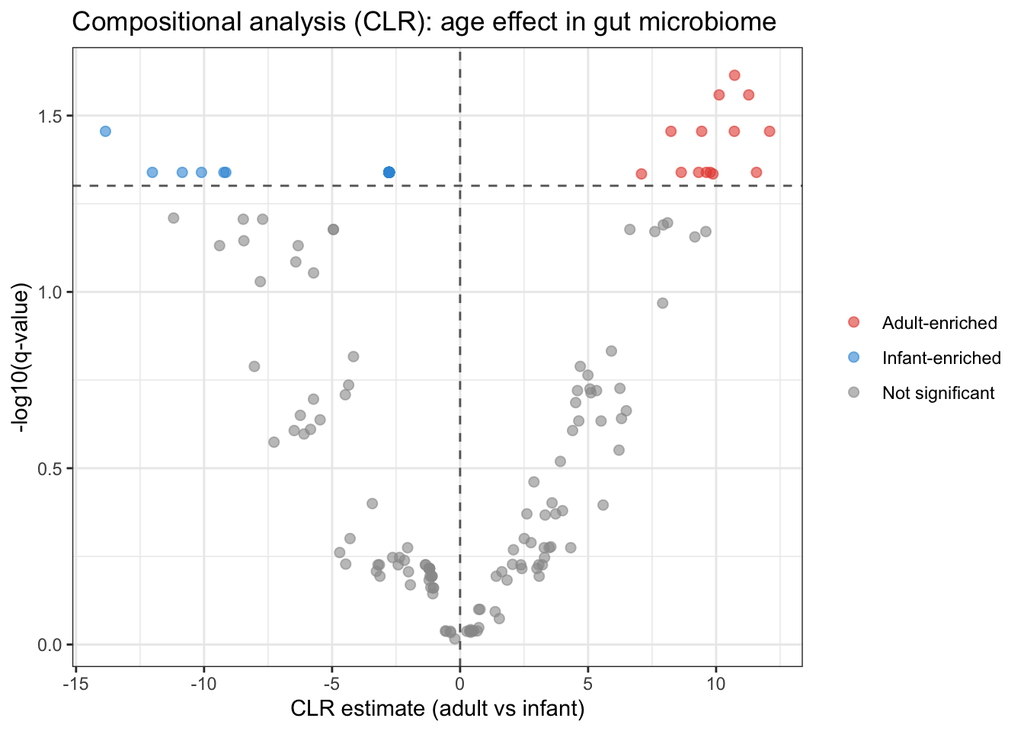

```r
# Volcano plot: CLR-based linear model
clr_age_adjusted_status_results %>%
  mutate(
    neg_log10_q = -log10(q_value),
    direction = case_when(
      q_value < 0.05 & estimate > 0 ~ "Adult-enriched",
      q_value < 0.05 & estimate < 0 ~ "Infant-enriched",
      TRUE ~ "Not significant"
    )
  ) %>%
  ggplot(aes(x = estimate, y = neg_log10_q, color = direction)) +
    geom_point(alpha = 0.6, size = 2) +
    scale_color_manual(values = c("Adult-enriched" = "#E74C3C", "Infant-enriched" = "#3498DB", "Not significant" = "grey60")) +
    geom_hline(yintercept = -log10(0.05), linetype = "dashed", color = "grey40") +
    geom_vline(xintercept = 0, linetype = "dashed", color = "grey40") +
    labs(x = "CLR estimate (adult vs infant)", y = "-log10(q-value)", color = NULL,
         title = "Compositional analysis (CLR): age effect in gut microbiome") +
    theme_bw()
```

Use this volcano plot as the compositionally aware reference analysis.

The next plot shows CLR effect size on the x-axis and orders taxa by q-value.

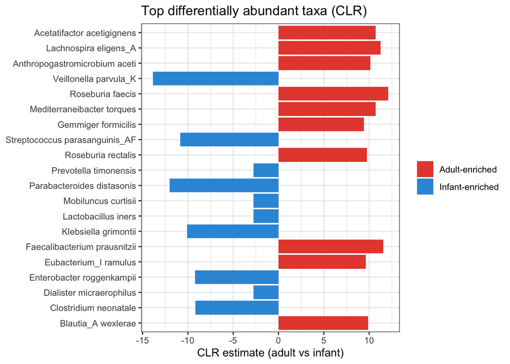

```r
# Bar chart of top significant taxa ordered by q-value (CLR)
bind_rows(
  clr_age_adjusted_status_results %>% filter(q_value < 0.05) %>% arrange(estimate) %>% head(10),
  clr_age_adjusted_status_results %>% filter(q_value < 0.05) %>% arrange(-estimate) %>% head(10)
) %>%
  distinct() %>%
  mutate(
    label = species,
    direction = ifelse(estimate > 0, "Adult-enriched", "Infant-enriched")
  ) %>%
  ggplot(aes(x = reorder(label, -q_value), y = estimate, fill = direction)) +
    geom_col() +
    coord_flip() +
    scale_fill_manual(values = c("Adult-enriched" = "#E74C3C", "Infant-enriched" = "#3498DB")) +
    labs(x = NULL, y = "CLR estimate (adult vs infant)", fill = NULL,
         title = "Top differentially abundant taxa (CLR)") +
    theme_bw()
```

Taxa that change strongly under CLR are important interpretation cases.

## Compare differential abundance methods

Details: [10. Compare Differential Abundance Methods](https://github.com/GeoGenetics/NBIB25004U-Metagenomics-2026/wiki/Week-21-practical-sessions#-10-compare-differential-abundance-methods). The hidden chunk below joins effect estimates and q-values from all methods.

First, count how many taxa each method detects at `q < 0.05`.

```r
# Significant taxa per method (q < 0.05)
sig_summary <- tibble(
  method = c("Wilcoxon", "GLM", "GLM adjusted", "CLR"),
  n_significant = c(
    sum(wilcox_results$q_value < 0.05, na.rm = TRUE),
    sum(glm_age_results$q_value < 0.05, na.rm = TRUE),
    sum(glm_age_adjusted_status_results$q_value < 0.05, na.rm = TRUE),
    sum(clr_age_adjusted_status_results$q_value < 0.05, na.rm = TRUE)
  )
)

sig_summary
```

```
## # A tibble: 4 × 2
##   method       n_significant
##   <chr>                <int>
## 1 Wilcoxon                 8
## 2 GLM                     16
## 3 GLM adjusted            16
## 4 CLR                     50
```

Large differences in this count show that method choice affects the result set.

Next, identify taxa significant in all four methods.

```r
# Taxa significant in all four methods
all_methods_sig <- comparison_results %>%
  filter(wilcox_q < 0.05, glm_q < 0.05, glm_adj_q < 0.05, clr_q < 0.05) %>%
  select(genus, species, wilcox_q, glm_q, glm_adj_q, clr_q) %>%
  arrange(wilcox_q)

all_methods_sig
```

```
## # A tibble: 6 × 6
##   genus            species                     wilcox_q   glm_q glm_adj_q  clr_q
##   <chr>            <chr>                          <dbl>   <dbl>     <dbl>  <dbl>
## 1 Gemmiger         Gemmiger formicilis           0.0405 0.0138    0.0383  0.0350
## 2 Acetatifactor    Acetatifactor acetigignens    0.0405 0.00758   0.0195  0.0243
## 3 Lachnospira      Lachnospira eligens_A         0.0413 0.00758   0.0135  0.0276
## 4 Blautia_A        Blautia_A wexlerae            0.0413 0.00264   0.00505 0.0463
## 5 Roseburia        Roseburia rectalis            0.0413 0.00283   0.0102  0.0458
## 6 Faecalibacterium Faecalibacterium prausnitz…   0.0469 0.00655   0.0135  0.0458
```

These taxa are the strongest consensus candidates. Use [13. How to Read the Practical Results](https://github.com/GeoGenetics/NBIB25004U-Metagenomics-2026/wiki/Week-21-practical-sessions#-13-how-to-read-the-practical-results) for the interpretation checklist.

The next scatter plot tests whether status adjustment changes the age-effect estimates.

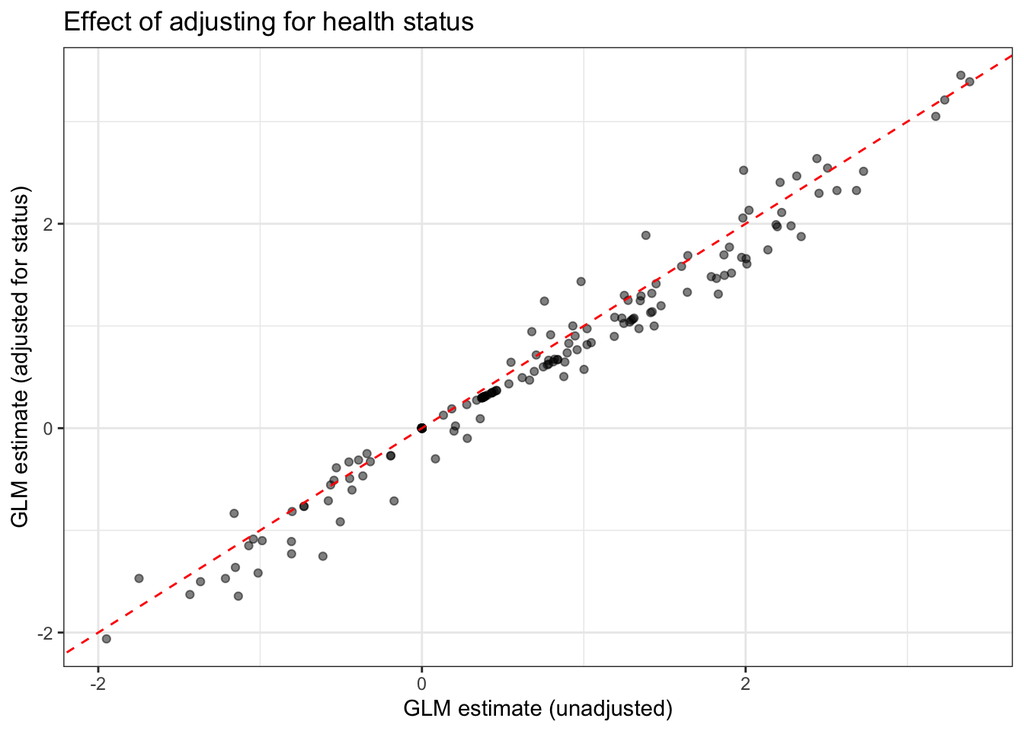

```r
# Effect size comparison: GLM unadjusted vs GLM adjusted for status
comparison_results %>%
  ggplot(aes(x = glm_estimate, y = glm_adj_estimate)) +
    geom_point(alpha = 0.5) +
    geom_abline(slope = 1, intercept = 0, linetype = "dashed", color = "red") +
    labs(
      x = "GLM estimate (unadjusted)",
      y = "GLM estimate (adjusted for status)",
      title = "Effect of adjusting for health status"
    ) +
    theme_bw()
```

Points far from the diagonal are taxa whose age effect changes after adjusting for status.

The next scatter plot compares adjusted GLM and CLR effect sizes.

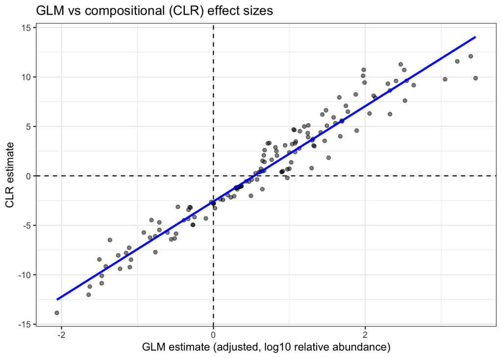

```r
# Effect size comparison: GLM adjusted vs CLR
comparison_results %>%
  ggplot(aes(x = glm_adj_estimate, y = clr_estimate)) +
    geom_point(alpha = 0.5) +
    geom_smooth(method = "lm", se = FALSE, color = "blue") +
    geom_hline(yintercept = 0, linetype = "dashed") +
    geom_vline(xintercept = 0, linetype = "dashed") +
    labs(
      x = "GLM estimate (adjusted, log10 relative abundance)",
      y = "CLR estimate",
      title = "GLM vs compositional (CLR) effect sizes"
    ) +
    theme_bw()
```

Outliers are taxa where compositional correction most changes the inferred effect.

The next plot counts how many methods support each taxon.

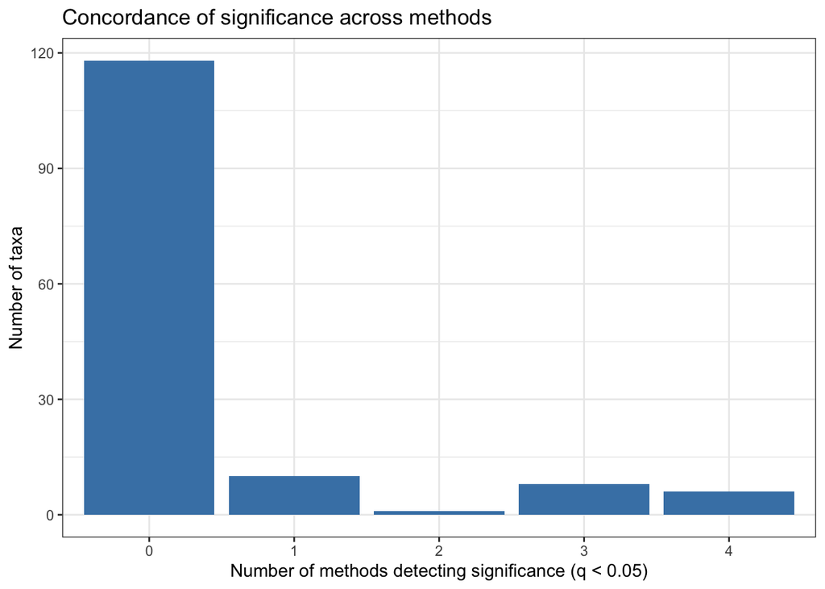

```r
# Q-value concordance across all methods
comparison_results %>%
  mutate(
    sig_wilcox  = wilcox_q  < 0.05,
    sig_glm     = glm_q     < 0.05,
    sig_glm_adj = glm_adj_q < 0.05,
    sig_clr     = clr_q     < 0.05,
    n_methods_significant = sig_wilcox + sig_glm + sig_glm_adj + sig_clr
  ) %>%
  count(n_methods_significant) %>%
  filter(!is.na(n_methods_significant)) %>%
  ggplot(aes(x = factor(n_methods_significant), y = n)) +
    geom_col(fill = "steelblue") +
    labs(
      x = "Number of methods detecting significance (q < 0.05)",
      y = "Number of taxa",
      title = "Concordance of significance across methods"
    ) +
    theme_bw()
```

Use this distribution to separate broad agreement from method-specific detections.

The heatmap below shows q-value strength and direction for taxa significant in at least one method.

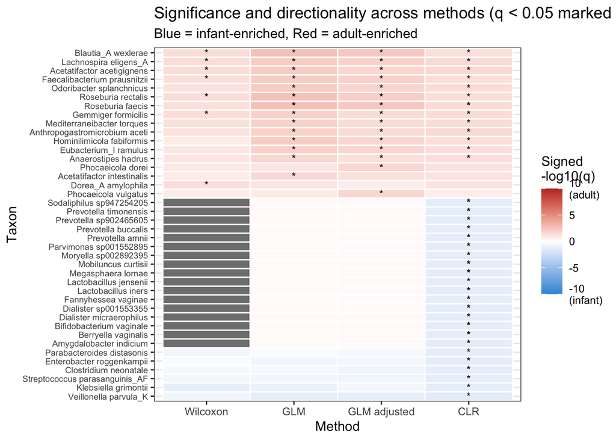

```r
# Significance heatmap with directionality: signed -log10(q) across all methods for taxa significant in at least one
heatmap_data <- comparison_results %>%
  filter(wilcox_q < 0.05 | glm_q < 0.05 | glm_adj_q < 0.05 | clr_q < 0.05) %>%
  mutate(label = species) %>%
  select(label,
         wilcox_q, glm_q, glm_adj_q, clr_q,
         wilcox_log2fc, glm_estimate, glm_adj_estimate, clr_estimate) %>%
  pivot_longer(cols = c(wilcox_q, glm_q, glm_adj_q, clr_q),
               names_to = "method", values_to = "q_value") %>%
  mutate(
    direction = case_when(
      method == "wilcox_q"    ~ wilcox_log2fc,
      method == "glm_q"       ~ glm_estimate,
      method == "glm_adj_q"   ~ glm_adj_estimate,
      method == "clr_q"       ~ clr_estimate
    ),
    signed_neg_log10_q = sign(direction) * pmin(-log10(q_value), 10),
    method = factor(method,
                    levels = c("wilcox_q", "glm_q", "glm_adj_q", "clr_q"),
                    labels = c("Wilcoxon", "GLM", "GLM adjusted", "CLR"))
  )

taxon_order <- heatmap_data %>%
  group_by(label) %>%
  summarise(mean_signed = mean(signed_neg_log10_q, na.rm = TRUE), .groups = "drop") %>%
  arrange(mean_signed) %>%
  pull(label)

heatmap_data %>%
  mutate(label = factor(label, levels = taxon_order)) %>%
  ggplot(aes(x = method, y = label, fill = signed_neg_log10_q)) +
    geom_tile(color = "white", linewidth = 0.5) +
    geom_text(aes(label = ifelse(q_value < 0.05, "*", "")), color = "black", size = 3) +
    scale_fill_gradient2(
      low = "#3498DB", mid = "white", high = "#C0392B",
      midpoint = 0, limits = c(-10, 10),
      name = "Signed\n-log10(q)",
      breaks = c(-10, -5, 0, 5, 10),
      labels = c("-10\n(infant)", "-5", "0", "5", "10\n(adult)")
    ) +
    labs(x = "Method", y = "Taxon",
         title = "Significance and directionality across methods (q < 0.05 marked with *)",
         subtitle = "Blue = infant-enriched, Red = adult-enriched") +
    theme_bw() +
    theme(axis.text.y = element_text(size = 7))
```

Rows with consistent colour and stars across methods are the most stable findings.

The final method-comparison plot checks whether Wilcoxon and CLR agree on direction.

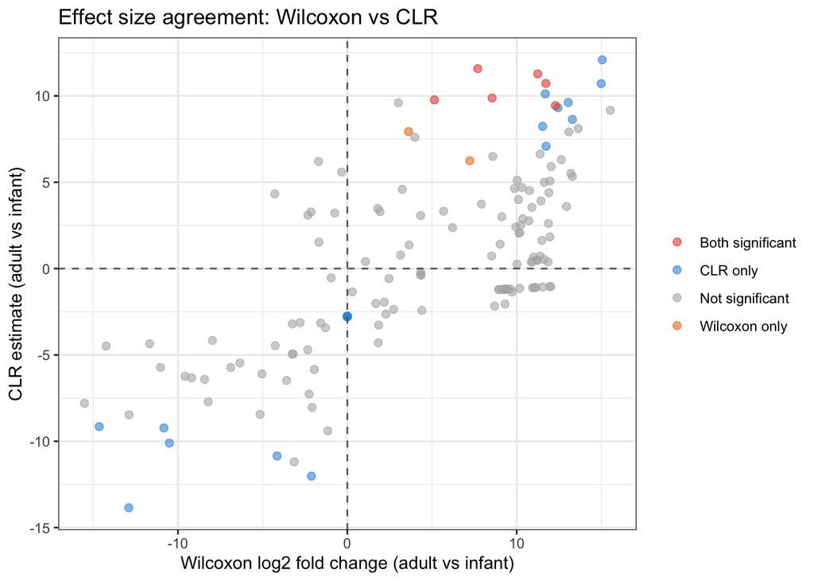

```r
# Cross-method effect size agreement: Wilcoxon log2FC vs CLR estimate
comparison_results %>%
  mutate(
    sig_category = case_when(
      wilcox_q < 0.05 & clr_q < 0.05 ~ "Both significant",
      wilcox_q < 0.05               ~ "Wilcoxon only",
      clr_q < 0.05                  ~ "CLR only",
      TRUE                          ~ "Not significant"
    )
  ) %>%
  ggplot(aes(x = wilcox_log2fc, y = clr_estimate, color = sig_category)) +
    geom_point(alpha = 0.6, size = 2) +
    scale_color_manual(values = c(
      "Both significant" = "#E74C3C",
      "Wilcoxon only"    = "#E67E22",
      "CLR only"         = "#3498DB",
      "Not significant"  = "grey70"
    )) +
    geom_hline(yintercept = 0, linetype = "dashed", color = "grey40") +
    geom_vline(xintercept = 0, linetype = "dashed", color = "grey40") +
    labs(x = "Wilcoxon log2 fold change (adult vs infant)",
         y = "CLR estimate (adult vs infant)",
         color = NULL,
         title = "Effect size agreement: Wilcoxon vs CLR") +
    theme_bw()
```

Same-sign points indicate agreement between the simplest and most compositionally aware univariate methods.

# Multivariate statistics

These sections analyse all gut taxa jointly on the CLR scale. PCA is unconstrained; RDA is constrained by metadata.

## PCA of CLR-transformed gut profiles

Details: [11. PCA of CLR-Transformed Gut Profiles](https://github.com/GeoGenetics/NBIB25004U-Metagenomics-2026/wiki/Week-21-practical-sessions#-11-pca-of-clr-transformed-gut-profiles). Build a gut-only CLR matrix and inspect the largest unconstrained community gradients.

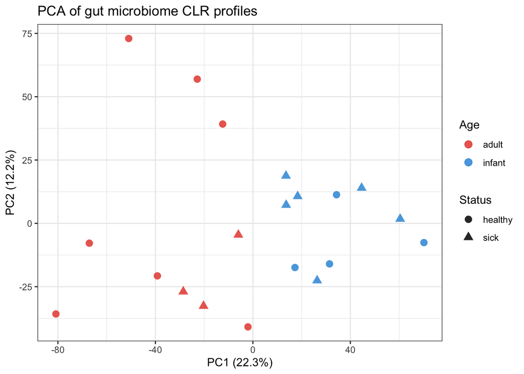

```r
gut_clr_mat <- dat_clr %>%
  filter(body_site == "gut") %>%
  select(sample_id, taxon, clr) %>%
  pivot_wider(names_from = taxon, values_from = clr) %>%
  column_to_rownames("sample_id") %>%
  as.matrix()

gut_meta <- meta_clr[rownames(gut_clr_mat), ] %>% as("data.frame")

gut_pca <- prcomp(gut_clr_mat, center = TRUE, scale. = FALSE)

pca_scores <- as.data.frame(gut_pca$x[, 1:2]) %>%
  rownames_to_column("sample_id") %>%
  left_join(gut_meta %>% rownames_to_column("sample_id"), by = "sample_id")

pca_var <- round(100 * gut_pca$sdev^2 / sum(gut_pca$sdev^2), 1)

pca_scores %>%
  ggplot(aes(x = PC1, y = PC2, color = age, shape = status)) +
    geom_point(size = 3, alpha = 0.85) +
    scale_color_manual(values = c("adult" = "#E74C3C", "infant" = "#3498DB")) +
    scale_shape_manual(values = c("healthy" = 16, "sick" = 17)) +
    labs(x = paste0("PC1 (", pca_var[1], "%)"),
         y = paste0("PC2 (", pca_var[2], "%)"),
         color = "Age", shape = "Status",
         title = "PCA of gut microbiome CLR profiles") +
    theme_bw()
```

Use PCA to see whether age or health status align with the strongest overall community gradients.

## Constrained ordination with RDA

Details: [12. Constrained Ordination with RDA](https://github.com/GeoGenetics/NBIB25004U-Metagenomics-2026/wiki/Week-21-practical-sessions#-12-constrained-ordination-with-rda). Fit an RDA on the gut CLR matrix constrained by age and health status.

```r
rda_age <- rda(gut_clr_mat ~ age + status, data = gut_meta)
```

The sample order in `gut_meta` must match the rows of `gut_clr_mat`.

Use permutation ANOVA to test the constrained model and each predictor.

```r
anova(rda_age, permutations = 999)
```

```
## Permutation test for rda under reduced model
## Permutation: free
## Number of permutations: 999
##
## Model: rda(formula = gut_clr_mat ~ age + status, data = gut_meta)
##          Df Variance      F Pr(>F)
## Model     2   1629.3 2.3787  0.001 ***
## Residual 17   5822.3
## ---
## Signif. codes:  0 '***' 0.001 '**' 0.01 '*' 0.05 '.' 0.1 ' ' 1
```

```r
anova(rda_age, by = "term", permutations = 999)
```

```
## Permutation test for rda under reduced model
## Terms added sequentially (first to last)
## Permutation: free
## Number of permutations: 999
##
## Model: rda(formula = gut_clr_mat ~ age + status, data = gut_meta)
##          Df Variance      F Pr(>F)
## age       1   1264.9 3.6933  0.001 ***
## status    1    364.4 1.0640  0.323
## Residual 17   5822.3
## ---
## Signif. codes:  0 '***' 0.001 '**' 0.01 '*' 0.05 '.' 0.1 ' ' 1
```

Extract RDA1 taxon scores to rank the taxa driving the primary constrained axis.

```r
rda_site_scores_raw <- scores(rda_age, display = "sites")
rda1_sign <- ifelse(
  mean(rda_site_scores_raw[gut_meta$age == "adult", "RDA1"], na.rm = TRUE) >=
    mean(rda_site_scores_raw[gut_meta$age == "infant", "RDA1"], na.rm = TRUE),
  1, -1
)

taxon_scores <- scores(rda_age, display = "species")[, 1] * rda1_sign

rda_taxa <- tibble(
  taxon = names(taxon_scores),
  rda1_loading = taxon_scores
) %>%
  arrange(desc(abs(rda1_loading)))
```

The `rda_taxa` table ranks taxa by absolute loading magnitude.

The biplot below shows samples, predictors and the top RDA1 taxa in the same constrained ordination space.

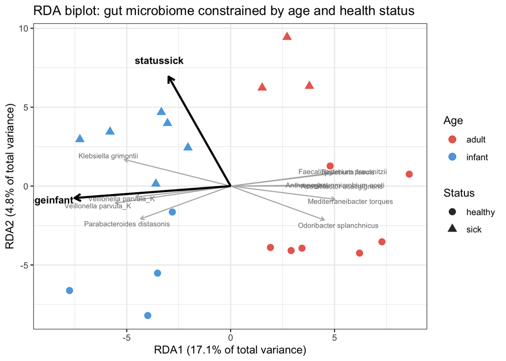

```r
eig <- rda_age$CCA$eig
pct1 <- round(eig[1] / rda_age$tot.chi * 100, 1)
pct2 <- round(eig[2] / rda_age$tot.chi * 100, 1)

site_scores <- scores(rda_age, display = "sites") %>%
  as.data.frame() %>%
  mutate(RDA1 = RDA1 * rda1_sign) %>%
  rownames_to_column("sample_id") %>%
  left_join(gut_meta %>% rownames_to_column("sample_id"), by = "sample_id")

biplot_scores <- scores(rda_age, display = "bp") %>%
  as.data.frame() %>%
  mutate(RDA1 = RDA1 * rda1_sign) %>%
  rownames_to_column("variable")

top_species_scores <- scores(rda_age, display = "species") %>%
  as.data.frame() %>%
  mutate(RDA1 = RDA1 * rda1_sign) %>%
  rownames_to_column("taxon") %>%
  inner_join(rda_taxa %>% head(10), by = "taxon") %>%
  left_join(tax_clr %>% rownames_to_column("taxon"), by = "taxon") %>%
  mutate(label = species)

# Scale arrows so the longest reaches ~80 % of the site score range
site_range <- max(abs(c(site_scores$RDA1, site_scores$RDA2)))
arrow_scale   <- site_range * 0.8 /
  max(sqrt(biplot_scores$RDA1^2   + biplot_scores$RDA2^2))
species_scale <- site_range * 0.6 /
  max(sqrt(top_species_scores$RDA1^2 + top_species_scores$RDA2^2))

biplot_scores      <- biplot_scores      %>% mutate(RDA1 = RDA1 * arrow_scale,   RDA2 = RDA2 * arrow_scale)
top_species_scores <- top_species_scores %>% mutate(RDA1 = RDA1 * species_scale, RDA2 = RDA2 * species_scale)

ggplot() +
  geom_point(data = site_scores,
             aes(x = RDA1, y = RDA2, color = age, shape = status),
             size = 3, alpha = 0.85) +
  geom_segment(data = top_species_scores,
               aes(x = 0, y = 0, xend = RDA1, yend = RDA2),
               arrow = arrow(length = unit(0.15, "cm")),
               color = "grey70", linewidth = 0.5) +
  geom_text(data = top_species_scores,
            aes(x = RDA1 * 1.15, y = RDA2 * 1.15, label = label),
            size = 2.5, color = "grey50") +
  geom_segment(data = biplot_scores,
               aes(x = 0, y = 0, xend = RDA1, yend = RDA2),
               arrow = arrow(length = unit(0.25, "cm")),
               color = "black", linewidth = 1) +
  geom_text(data = biplot_scores,
            aes(x = RDA1 * 1.15, y = RDA2 * 1.15, label = variable),
            size = 3.5, fontface = "bold", color = "black") +
  scale_color_manual(values = c("adult" = "#E74C3C", "infant" = "#3498DB")) +
  scale_shape_manual(values = c("healthy" = 16, "sick" = 17)) +
  labs(x = paste0("RDA1 (", pct1, "% of total variance)"),
       y = paste0("RDA2 (", pct2, "% of total variance)"),
       color = "Age", shape = "Status",
       title = "RDA biplot: gut microbiome constrained by age and health status") +
  theme_bw()
```

Look for age separation among sample points and for taxa arrows aligned with that gradient.

The final plot ranks the strongest RDA1 taxon loadings directly.

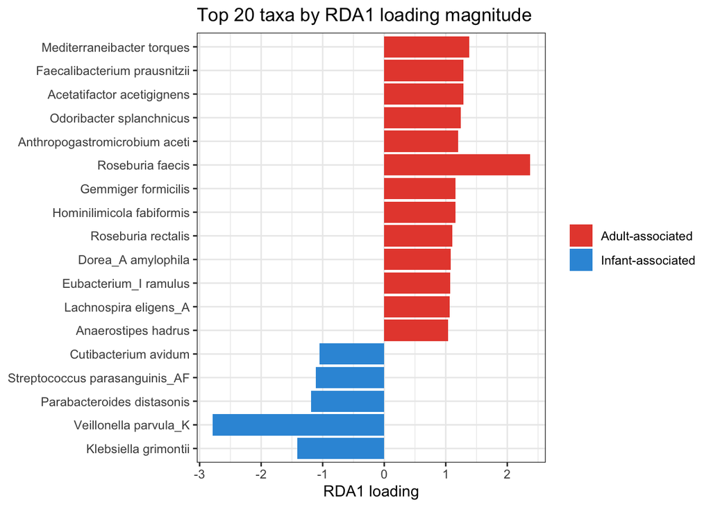

```r
rda_taxa %>%
  head(20) %>%
  left_join(tax_clr %>% rownames_to_column("taxon"), by = "taxon") %>%
  mutate(
    label = species,
    direction = ifelse(rda1_loading > 0, "Adult-associated", "Infant-associated")
  ) %>%
  ggplot(aes(x = reorder(label, rda1_loading), y = rda1_loading, fill = direction)) +
    geom_col() +
    coord_flip() +
    scale_fill_manual(values = c("Adult-associated" = "#E74C3C", "Infant-associated" = "#3498DB")) +
    labs(x = NULL, y = "RDA1 loading", fill = NULL,
         title = "Top 20 taxa by RDA1 loading magnitude") +
    theme_bw()
```

Compare these RDA drivers with the consensus taxa from the univariate methods.

The final comparison links the multivariate RDA loadings to the CLR-based univariate age estimates.

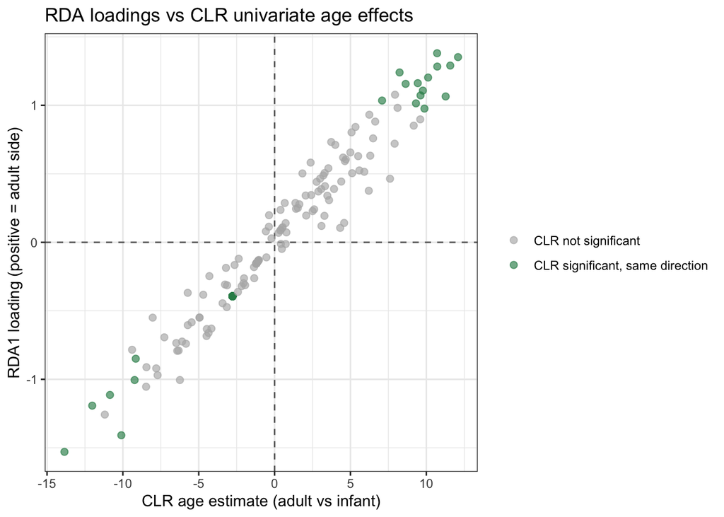

```r
rda_clr_comparison <- rda_taxa %>%
  left_join(
    clr_age_adjusted_status_results %>%
      select(taxon, genus, species,
             clr_estimate = estimate,
             clr_q = q_value),
    by = "taxon"
  ) %>%
  mutate(
    direction_agreement = sign(rda1_loading) == sign(clr_estimate),
    clr_result = case_when(
      clr_q < 0.05 & direction_agreement ~ "CLR significant, same direction",
      clr_q < 0.05                      ~ "CLR significant, opposite direction",
      TRUE                              ~ "CLR not significant"
    )
  )

rda_clr_comparison %>%
  ggplot(aes(x = clr_estimate, y = rda1_loading, color = clr_result)) +
    geom_hline(yintercept = 0, linetype = "dashed", color = "grey40") +
    geom_vline(xintercept = 0, linetype = "dashed", color = "grey40") +
    geom_point(alpha = 0.65, size = 2) +
    scale_color_manual(values = c(
      "CLR significant, same direction"     = "#2E8B57",
      "CLR significant, opposite direction" = "#E67E22",
      "CLR not significant"                 = "grey70"
    )) +
    labs(x = "CLR age estimate (adult vs infant)",
         y = "RDA1 loading (positive = adult side)",
         color = NULL,
         title = "RDA loadings vs CLR univariate age effects") +
    theme_bw()
```

Points in the upper-right and lower-left quadrants agree in direction between RDA and CLR.

```r
rda_clr_comparison %>%
  arrange(desc(abs(rda1_loading))) %>%
  select(genus, species, rda1_loading, clr_estimate, clr_q, direction_agreement) %>%
  head(20)
```

```
## # A tibble: 20 × 6
##    genus            species rda1_loading clr_estimate  clr_q direction_agreement
##    <chr>            <chr>          <dbl>        <dbl>  <dbl> <lgl>
##  1 Veillonella      Veillo…        -1.53       -13.9  0.0350 TRUE
##  2 Klebsiella       Klebsi…        -1.41       -10.1  0.0458 TRUE
##  3 Mediterraneibac… Medite…         1.38        10.7  0.0350 TRUE
##  4 Roseburia        Rosebu…         1.35        12.1  0.0350 TRUE
##  5 Faecalibacterium Faecal…         1.29        11.6  0.0458 TRUE
##  6 Acetatifactor    Acetat…         1.28        10.7  0.0243 TRUE
##  7 Veillonella      Veillo…        -1.26       -11.2  0.0617 TRUE
##  8 Odoribacter      Odorib…         1.24         8.24 0.0350 TRUE
##  9 Anthropogastrom… Anthro…         1.20        10.1  0.0276 TRUE
## 10 Parabacteroides  Paraba…        -1.19       -12.0  0.0458 TRUE
## 11 Gemmiger         Gemmig…         1.16         9.44 0.0350 TRUE
## 12 Hominilimicola   Homini…         1.16         8.64 0.0458 TRUE
## 13 Streptococcus    Strept…        -1.11       -10.9  0.0458 TRUE
## 14 Roseburia        Rosebu…         1.11         9.77 0.0458 TRUE
## 15 Dorea_A          Dorea_…         1.08         7.94 0.0645 TRUE
## 16 Eubacterium_I    Eubact…         1.07         9.62 0.0458 TRUE
## 17 Lachnospira      Lachno…         1.06        11.3  0.0276 TRUE
## 18 Cutibacterium    Cutiba…        -1.05        -8.47 0.0622 TRUE
## 19 Anaerostipes     Anaero…         1.03         7.08 0.0463 TRUE
## 20 Roseburia        Rosebu…         1.01         9.32 0.0458 TRUE
```

Use [13. How to Read the Practical Results](https://github.com/GeoGenetics/NBIB25004U-Metagenomics-2026/wiki/Week-21-practical-sessions#-13-how-to-read-the-practical-results) for the final interpretation.